# Business Statistics with R: Payday Loan study case

Gibran Makyanie

A financial conduct regulator needs to investigate the effect of payday loans. A dataset of a survey from 5,000 customers where they reported their well-being and a measure of their socio-economic status linked to their credit file is available.

Two questions arose: 1. Does receiving a payday loan change well-being? If so, how much? 2. Does taking payday loan makes people more or less likely to experience an adverse credit event?

```r
rm(list=ls())
library(tidyverse)
library(DataExplorer)
library(emmeans)
library(gridExtra) # for grid.arrange()
library(gmodels)
library(MASS)
options(width=100)
```

```r
# --------- import data
payday <- read.csv('payday.csv')

# --------- variable check
payday$credit.score <- as.numeric(payday$credit.score)
payday$SES <- as.numeric(payday$SES)
payday$well.being <- as.numeric(payday$well.being)
#payday$adverse.credit.event <- factor(payday$adverse.credit.event, levels = c(0,1), labels = c("no adverse", "adverse"))
payday$id <- NULL

view(payday)
str(payday)
```

```
## 'data.frame':    5000 obs. of  5 variables:
##  $ credit.score        : num  590 440 470 480 570 550 550 580 540 560 ...
##  $ SES                 : num  16 14 13 14 18 17 15 18 16 14 ...
##  $ loan                : int  1 0 0 0 1 1 1 1 1 1 ...
##  $ well.being          : num  5 4 3 2 7 7 4 7 5 6 ...
##  $ adverse.credit.event: int  0 1 0 1 0 0 1 0 0 1 ...
```

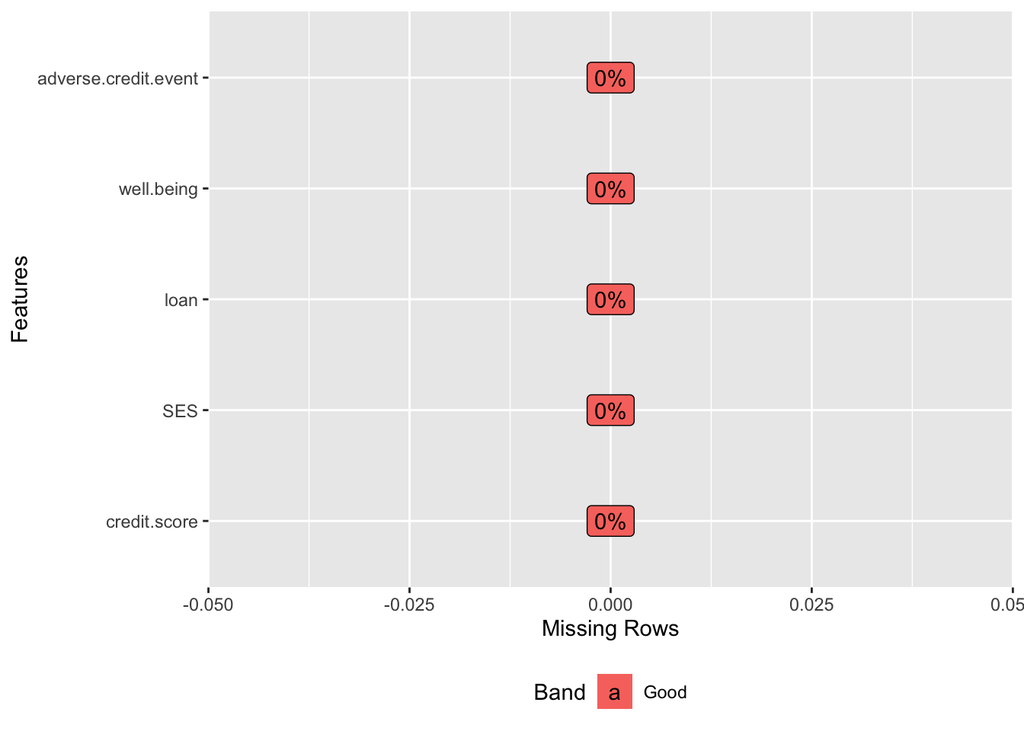

```r
plot_missing(payday)
```

# Data Dictionary

| Variable | Description |
| --- | --- |
| id | Customer ID |
| credit.score | Customer’s credit score [400 to 600] |
| SES | People’s socio-economic status, with higher scores indicating higer status [1 to 26] |
| loan | A dummy variable indicating whether or not people were given the payday loan [0: no or 1: yes] |
| well.being | Customer’s self-reported well-being on a 1-7 scale, with 7 being the highest well-being [1 to 7] |
| adverse.credit.event | A dummy indicating whether there was an adverse credit event in the next year [0: no or 1: yes] |

# Does receiving a payday loan change well-being? If so, how much?

> Yes, loan significantly affects well-being by a decrease of .132 in well-being score if one receives payday loan, 95% CI[(-.242) – (-.022)], and no decrease otherwise, given SES and credit score held constant.

Individually, loan, SES, and credit score have significant effect and a positive correlation when used as a predictor of well-being. Put it simply, as one increases, well-being increases too. However, well-being is best explained by using the combination of loan, credit.score, and SES as predictors using a multiple regression model, $R^2$ = .694. Figure 1 describes how each predictor changes well-being when used together.

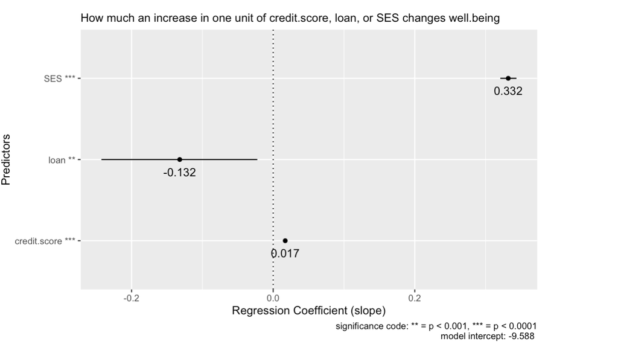

Figure 1. Regression coefficient of credit score, loan, and SES to describe the change in well-being per each unit increase.

# Does taking payday loan makes people more or less likely to experience an adverse credit event?

> Those taking payday loan are less likely to experience adverse credit event. And Social Economic Status does not have a significant effect on adverse credit event nor on the relationship loan has with adverse credit event.

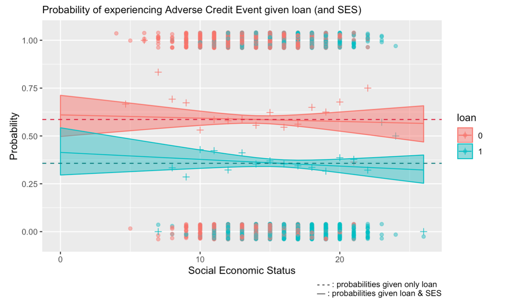

Figure 2. A comparison of probability estimate on adverse credit event given loan (and SES)

Figure 2 describes the difference in probability of experiencing adverse credit event (ACE) when receiving a loan and a comparison of how insignificant SES affect the probabilities as SES increases. The dashed line is the probability estimate for ACE given a loan or not (without SES), the dots describes the individuals who either experienced ACE or not, the +s are the proportion of ACE in each SES rank, while the line and ribbon are the fit of a logistic regression model and its 95% CI given SES.

The probability of those taking payday loan to experience ACE, .357 95% CI[.339 – .376], is lower than those who do not, .586 95% CI[.566 – .606], about an absolute .229 change in probability.

# In-depth Analysis

```r
# --------- Exploratory Data Analysis

summary(payday)
```

```
##   credit.score        SES          loan          well.being    adverse.credit.event
##  Min.   :400.0   Min.   : 4   Min.   :0.0000   Min.   :1.000   Min.   :0.0000
##  1st Qu.:450.0   1st Qu.:13   1st Qu.:0.0000   1st Qu.:3.000   1st Qu.:0.0000
##  Median :500.0   Median :15   Median :1.0000   Median :4.000   Median :0.0000
##  Mean   :499.3   Mean   :15   Mean   :0.5178   Mean   :4.011   Mean   :0.4674
##  3rd Qu.:550.0   3rd Qu.:17   3rd Qu.:1.0000   3rd Qu.:5.000   3rd Qu.:1.0000
##  Max.   :600.0   Max.   :26   Max.   :1.0000   Max.   :7.000   Max.   :1.0000
```

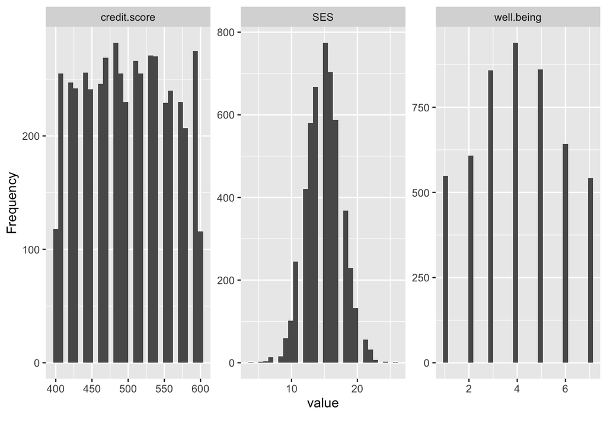

```r
plot_histogram(payday)
```

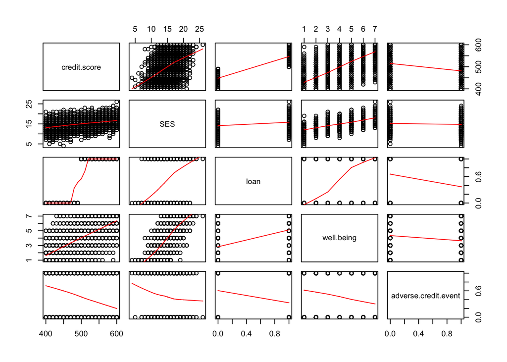

```r
pairs(payday, panel=panel.smooth)
```

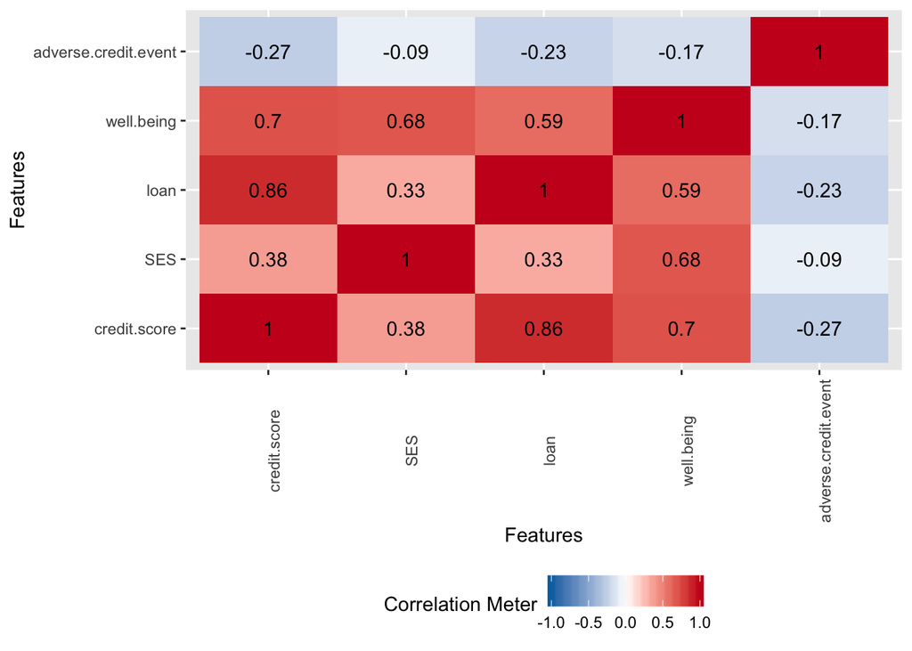

```r
plot_correlation(payday)
```

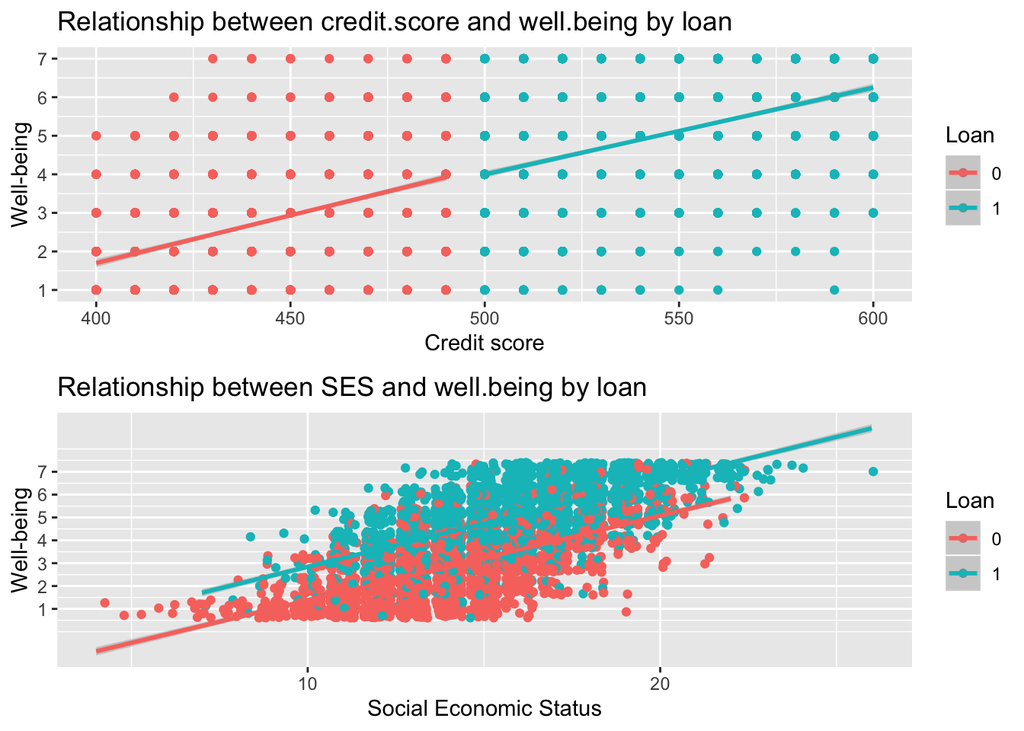

```r
grid.arrange(
    ggplot(payday, aes(y=well.being, x=credit.score,colour=as.factor(payday$loan))) + geom_point(mapping = aes(colour=as.factor(payday$loan))) + scale_y_continuous(breaks = 1:7) +labs(x="Credit score", y="Well-being",title="Relationship between credit.score and well.being by loan",col="Loan") + geom_smooth(method=lm),

    ggplot(payday, aes(y=well.being, x=SES,colour=as.factor(payday$loan))) + geom_jitter() +scale_y_continuous(breaks = 1:7)+ labs(x="Social Economic Status", y="Well-being",title="Relationship between SES and well.being by loan",col="Loan") +geom_smooth(method=lm))
```

```r
#  --------- Compute R^2 among variables to understand the multicoliniarity.
round((cor(payday))^2, digits = 3)
```

```
##                      credit.score   SES  loan well.being adverse.credit.event
## credit.score                1.000 0.148 0.743      0.494                0.071
## SES                         0.148 1.000 0.108      0.467                0.008
## loan                        0.743 0.108 1.000      0.354                0.053
## well.being                  0.494 0.467 0.354      1.000                0.030
## adverse.credit.event        0.071 0.008 0.053      0.030                1.000
```

`loan` and `credit.score` has relatively high correlation with each other ($R^2 = .743$), . However, `credit.score` ($R^2 = .494$) can explain well.being better than loan ($R^2 = .354$). Therefore, it is within expectation that `credit.score` might be a more significant independant variable than loan in a multiple regression for well.being.

```r
# --------- Linear regression on bivariate
LM_loan <- lm(well.being~ loan, data=payday)
LM_credit.score <- lm(well.being~ credit.score, data=payday)
LM_ses <- lm(well.being~ SES, data=payday)

# --------- Multiple regression models for well.being
LM_credit.loan <- lm(well.being~ credit.score + loan, data=payday) # model1, without SES
LM_credit.loan.ses <- lm(well.being ~ credit.score + loan + SES , data=payday)  # model2, including SES
```

`LM_credit.loan` has loan and credit.score as independent variables for well.being. While, `LM_credit.loan.ses` in addition to what `LM_credit.loan` has, SES is added.

```r
# --------- NHST whether the variables are significant in a bivariate setup
anova(LM_loan)
```

```
## Analysis of Variance Table
##
## Response: well.being
##             Df  Sum Sq Mean Sq F value    Pr(>F)
## loan         1  5852.6  5852.6  2738.6 < 2.2e-16 ***
## Residuals 4998 10680.9     2.1
## ---
## Signif. codes:  0 '***' 0.001 '**' 0.01 '*' 0.05 '.' 0.1 ' ' 1
```

```r
anova(LM_credit.score)
```

```
## Analysis of Variance Table
##
## Response: well.being
##                Df Sum Sq Mean Sq F value    Pr(>F)
## credit.score    1 8163.1  8163.1  4874.3 < 2.2e-16 ***
## Residuals    4998 8370.3     1.7
## ---
## Signif. codes:  0 '***' 0.001 '**' 0.01 '*' 0.05 '.' 0.1 ' ' 1
```

```r
anova(LM_ses)
```

```
## Analysis of Variance Table
##
## Response: well.being
##             Df Sum Sq Mean Sq F value    Pr(>F)
## SES          1 7722.4  7722.4  4380.5 < 2.2e-16 ***
## Residuals 4998 8811.0     1.8
## ---
## Signif. codes:  0 '***' 0.001 '**' 0.01 '*' 0.05 '.' 0.1 ' ' 1
```

```r
# --------- NHST whether the variance differ between multiple regression model with and without SES
#H0: LM_credit.loan == LM_credit.loan.ses ; HA: LM_credit.loan != LM_credit.loan.ses
anova(LM_credit.loan, LM_credit.loan.ses)
```

```
## Analysis of Variance Table
##
## Model 1: well.being ~ credit.score + loan
## Model 2: well.being ~ credit.score + loan + SES
##   Res.Df    RSS Df Sum of Sq      F    Pr(>F)
## 1   4997 8362.8
## 2   4996 5053.0  1    3309.8 3272.5 < 2.2e-16 ***
## ---
## Signif. codes:  0 '***' 0.001 '**' 0.01 '*' 0.05 '.' 0.1 ' ' 1
```

```r
# --------- NHST the significance of the variables
# For each variable... H0: model with variable == model without variable ; HA: model with variable != model without variable
anova(LM_credit.loan.ses)
```

```
## Analysis of Variance Table
##
## Response: well.being
##                Df Sum Sq Mean Sq   F value    Pr(>F)
## credit.score    1 8163.1  8163.1 8071.0331 < 2.2e-16 ***
## loan            1    7.5     7.5    7.4561  0.006344 **
## SES             1 3309.8  3309.8 3272.4871 < 2.2e-16 ***
## Residuals    4996 5053.0     1.0
## ---
## Signif. codes:  0 '***' 0.001 '**' 0.01 '*' 0.05 '.' 0.1 ' ' 1
```

All bivariate LMs has significant effect on `well.being`, but when put together, the significance of loan shifts to `credit.score`. This comes back again to the fact that `credit.score` and `loan` are highly correlated. But `credit.score` still have the upperhand when it comes to predicting `well.being`.

The `LM_credit.loan.ses` fits significantly better, F=3272.5 and p < .0001, with an increase of 0.2 in $R^2$ and a decrease in 3309 of RSS compared to `LM_credit.loan`. We can say that adding `SES` explains an additional 20% of the variance in well being and it is statistically significant.

All independent variables in `LM_credit.loan.ses` are significant, but compared to `credit.score` and `credit.score`, `loan` is the least significant, p=.006.

```r
# --------- the equation for wellbeing
summary(LM_credit.loan.ses)
```

```
##
## Call:
## lm(formula = well.being ~ credit.score + loan + SES, data = payday)
##
## Residuals:
##     Min      1Q  Median      3Q     Max
## -3.8283 -0.6951  0.0084  0.6656  3.7784
##
## Coefficients:
##                Estimate Std. Error t value Pr(>|t|)
## (Intercept)  -9.5881336  0.2233281 -42.933   <2e-16 ***
## credit.score  0.0173921  0.0005017  34.667   <2e-16 ***
## loan         -0.1324966  0.0561764  -2.359   0.0184 *
## SES           0.3322207  0.0058075  57.206   <2e-16 ***
## ---
## Signif. codes:  0 '***' 0.001 '**' 0.01 '*' 0.05 '.' 0.1 ' ' 1
##
## Residual standard error: 1.006 on 4996 degrees of freedom
## Multiple R-squared:  0.6944, Adjusted R-squared:  0.6942
## F-statistic:  3784 on 3 and 4996 DF,  p-value: < 2.2e-16
```

```r
cbind(coef(LM_credit.loan.ses), confint(LM_credit.loan.ses)) #Confidence interval of the estimate
```

```
##                                 2.5 %      97.5 %
## (Intercept)  -9.58813364 -10.02595471 -9.15031256
## credit.score  0.01739205   0.01640852  0.01837558
## loan         -0.13249660  -0.24262709 -0.02236611
## SES           0.33222068   0.32083547  0.34360589
```

`well.being` can be explained through the following equation: $\widehat{well.being} = -9.588 + 0.017 \times credit.score - 0.132 \times loan + 0.332 \times SES$

The negative coefficient of `loan` can be explained by the multiple colinearity with `credit.score`, the binary input, and the constraint of 7 scales of `well.being`. Simply put, `loan` balances `credit.score`’s impact by going to the opposite direction when `loan` == 1.

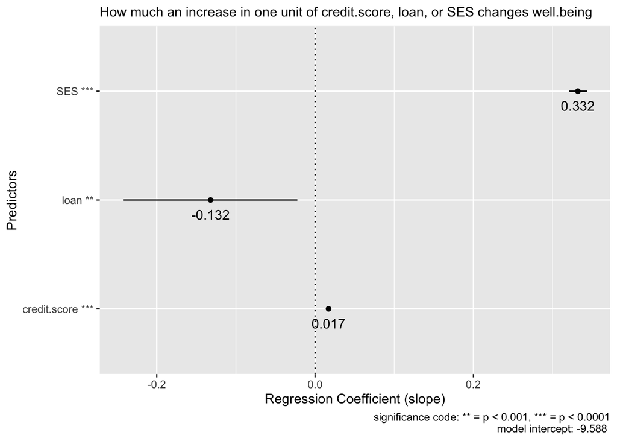

```r
# --------- plot prep
df_coeff <- as.data.frame(cbind(coef(LM_credit.loan.ses), confint(LM_credit.loan.ses)))
df_coeff <- mutate(df_coeff, id = rownames(df_coeff))
df_coeff <- anti_join(df_coeff, subset(df_coeff, id=='(Intercept)'))
df_coeff <- df_coeff %>%
  mutate(V1 = round(V1,digits = 3))

df_coeff$id[df_coeff$id == "credit.score"] <- "credit.score ***"
df_coeff$id[df_coeff$id == "loan"] <- "loan **"
df_coeff$id[df_coeff$id == "SES"] <- "SES ***"

# --------- plotting
ggplot(df_coeff , aes(y=as.factor(id), x=V1)) +
  geom_point() + geom_text(aes(label=V1),hjust=0.5, vjust=2) +
  labs(x="Regression Coefficient (slope)", y="Predictors",subtitle="How much an increase in one unit of credit.score, loan, or SES changes well.being", caption = "significance code: ** = p < 0.001, *** = p < 0.0001\n model intercept: -9.588 " ) +
  geom_segment(aes(x=`2.5 %`,xend=`97.5 %`,y=as.factor(id),yend=as.factor(id) )) +
  geom_vline(xintercept = 0, linetype='dotted')
```

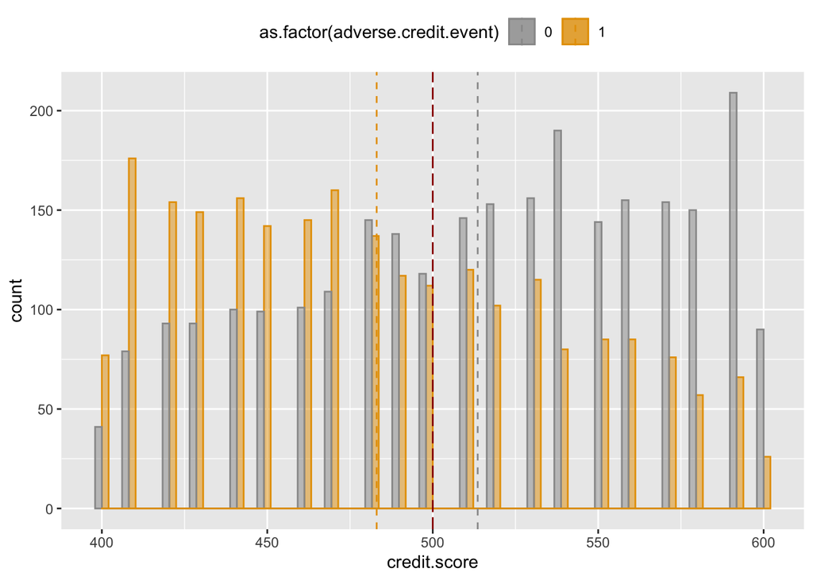

```r
# --------- Exploratory Data Analysis
mu <- payday %>%
    group_by(adverse.credit.event) %>%
    summarise(mean=mean(credit.score))

ggplot(payday, aes(x=credit.score, color=as.factor(adverse.credit.event), fill=as.factor(adverse.credit.event))) +
  geom_histogram(alpha =0.5, position="dodge", bins = 50)+
  geom_density(alpha=0.6)+
  geom_vline(data=mu, aes(xintercept=mean, color=as.factor(adverse.credit.event)),linetype="dashed")+
  geom_vline(xintercept = 500, colour="#990000", linetype="longdash")+
  scale_color_manual(values=c("#999999", "#E69F00", "#56B4E9"))+
  scale_fill_manual(values=c("#999999", "#E69F00", "#56B4E9"))+
  theme(legend.position="top")
```

```r
# --------- Build logistic regression model
adverse.by.loan.ses <- glm(adverse.credit.event~loan*SES , family=binomial, data=payday)
adverse.by.loan <- glm(adverse.credit.event~loan, family=binomial, data=payday)

summary(adverse.by.loan.ses)
```

```
##
## Call:
## glm(formula = adverse.credit.event ~ loan * SES, family = binomial,
##     data = payday)
##
## Deviance Residuals:
##     Min       1Q   Median       3Q      Max
## -1.3567  -0.9561  -0.9214   1.0392   1.4914
##
## Coefficients:
##              Estimate Std. Error z value Pr(>|z|)
## (Intercept)  0.447556   0.234026   1.912   0.0558 .
## loan        -0.795326   0.353494  -2.250   0.0245 *
## SES         -0.007080   0.016331  -0.434   0.6646
## loan:SES    -0.008152   0.023251  -0.351   0.7259
## ---
## Signif. codes:  0 '***' 0.001 '**' 0.01 '*' 0.05 '.' 0.1 ' ' 1
##
## (Dispersion parameter for binomial family taken to be 1)
##
##     Null deviance: 6910.2  on 4999  degrees of freedom
## Residual deviance: 6643.6  on 4996  degrees of freedom
## AIC: 6651.6
##
## Number of Fisher Scoring iterations: 4
```

```r
summary(adverse.by.loan)
```

```
##
## Call:
## glm(formula = adverse.credit.event ~ loan, family = binomial,
##     data = payday)
##
## Deviance Residuals:
##     Min       1Q   Median       3Q      Max
## -1.3282  -0.9396  -0.9396   1.0338   1.4355
##
## Coefficients:
##             Estimate Std. Error z value Pr(>|z|)
## (Intercept)  0.34772    0.04135   8.409   <2e-16 ***
## loan        -0.93659    0.05825 -16.080   <2e-16 ***
## ---
## Signif. codes:  0 '***' 0.001 '**' 0.01 '*' 0.05 '.' 0.1 ' ' 1
##
## (Dispersion parameter for binomial family taken to be 1)
##
##     Null deviance: 6910.2  on 4999  degrees of freedom
## Residual deviance: 6644.6  on 4998  degrees of freedom
## AIC: 6648.6
##
## Number of Fisher Scoring iterations: 4
```

```r
# --------- Get the probability of adverse credit event by loan and its estimation
adverse.by.loan.emm <- emmeans(adverse.by.loan, ~loan, type="response")
confint(adverse.by.loan.emm)
```

```
##  loan  prob      SE  df asymp.LCL asymp.UCL
##     0 0.586 0.01003 Inf     0.566     0.606
##     1 0.357 0.00942 Inf     0.339     0.376
##
## Confidence level used: 0.95
## Intervals are back-transformed from the logit scale
```

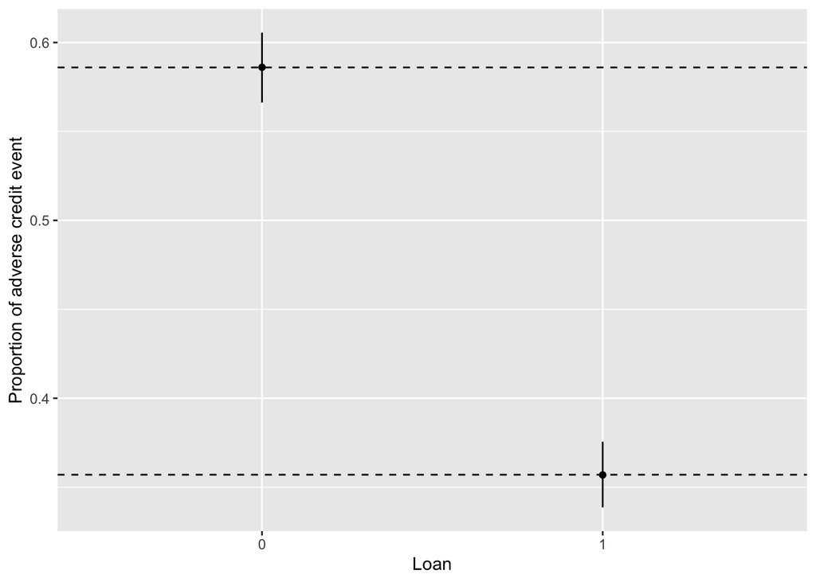

```r
# --------- Plot the probabilities
ggplot(summary(adverse.by.loan.emm), aes(x=as.factor(loan), y=prob, ymin=asymp.LCL, ymax=asymp.UCL)) + geom_point() + geom_linerange() + labs(x="Loan", y="Proportion of adverse credit event")  +
  geom_hline(yintercept = 0.586, lty=2) +
  geom_hline(yintercept = 0.357, lty=2)
```

```r
# --------- Prove that SES is insignificant for explaining adverse.credit.event
anova(adverse.by.loan.ses, test="Chisq")
```

```
## Analysis of Deviance Table
##
## Model: binomial, link: logit
##
## Response: adverse.credit.event
##
## Terms added sequentially (first to last)
##
##
##          Df Deviance Resid. Df Resid. Dev Pr(>Chi)
## NULL                      4999     6910.2
## loan      1  265.597      4998     6644.6   <2e-16 ***
## SES       1    0.913      4997     6643.7   0.3394
## loan:SES  1    0.123      4996     6643.6   0.7259
## ---
## Signif. codes:  0 '***' 0.001 '**' 0.01 '*' 0.05 '.' 0.1 ' ' 1
```

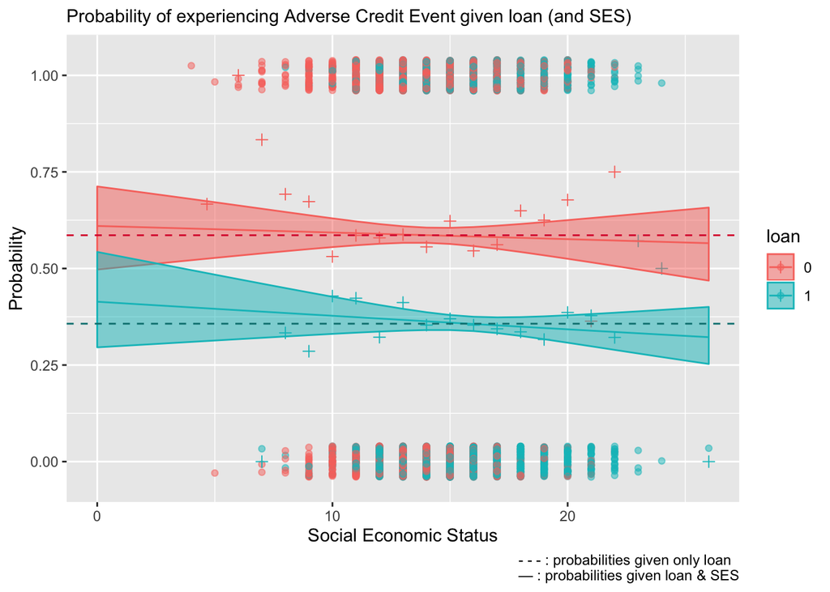

```r
# --------- Plot Prep
adverse.by.loan.ses.emm <- emmeans(adverse.by.loan.ses, ~loan*SES, at=list(SES=seq(0,26,1)), type="response")
ses.unique<- unique(payday$SES)
payday_t <- payday %>%
  mutate(SES.deciles=cut(SES, breaks=ses.unique, include.lowest=TRUE))

payday_t.loan.ses <- payday_t %>%
  group_by(SES.deciles,loan) %>%
  summarise(Proportion.adverse=mean(adverse.credit.event), decile.mean.ses=mean(SES))

payday_t$loan <- as.factor(payday_t$loan)
payday_t.loan.ses$loan <- as.factor(payday_t.loan.ses$loan)


sum_adverse.by.loan.ses.emm <- as.data.frame(summary(adverse.by.loan.ses.emm))
sum_adverse.by.loan.ses.emm$loan <- as.factor(sum_adverse.by.loan.ses.emm$loan)

# --------- Plotting mainplot
ggplot(sum_adverse.by.loan.ses.emm, aes(x=SES, col=loan, fill=loan,y=prob, ymin=asymp.LCL, ymax=asymp.UCL)) +
    geom_jitter(data=payday_t, mapping=aes(y=adverse.credit.event, x=SES, col=loan,ymin=NULL, ymax=NULL), height=0.04, width=0, alpha=0.5) +
    geom_point(data=payday_t.loan.ses, mapping=aes(y=Proportion.adverse, x=decile.mean.ses, col=loan, ymin=NULL, ymax=NULL), size=2, shape=3) +
    geom_ribbon(alpha = 0.5) +
    geom_line() +
    labs(x="Social Economic Status", y="Probability", caption="- - - : probabilities given only loan  \n  — : probabilities given loan & SES", subtitle = "Probability of experiencing Adverse Credit Event given loan (and SES)" ) +
  ylim(-0.05,1.05) +
  geom_hline(yintercept = 0.586, lty=2, color='#DC143C') +
  geom_hline(yintercept = 0.357, lty=2, color='#008080')
```